# Homework2

## Homework 2

In this homework you are going to implement neural network from scratch We are going to use the following notations for our derivation.

- $w_{ij}^l$ : weight between neuron $i$ at $(l-1)^{th}$ layer and neuron j at $l^{th}$ layer.
- $x_i$ : $i^{th}$ variable
- $z_i^l$ : input of neuron $i$ at layer $l$
- $a_i^l$ : output of neuron $i$ at layer $l$
- $b_i^l$ : bias for neuron $i$ at layer $l$
- $\hat{y}$ : output for neural network
1. In the first problem we are going to implement sigmoid activation functions according to following formula

$$f(x)= \frac{1}{1 + e^{-x}}$$

```python
def sigmoid(x):
    pass
```

```python
# Example for Problem 1
import numpy as np
x = np.array([0.2,0.5,0.3,0.8])
print(sigmoid(x))
```

```
[0.549834   0.62245933 0.57444252 0.68997448]
```

1. Now implement the derivative of the sigmoid function according to following formula

$$f(x)= \frac{1}{1 + e^{-x}}$$$$f'(x)= (1-f(x))*f(x)$$

```python
def sigmoid_prime(x):
    pass
```

```python
# Example for Problem 2
x = np.array([0.2,0.5,0.3,0.8])
print(sigmoid_prime(x))
```

```
[0.24751657 0.23500371 0.24445831 0.2139097 ]
```

1. Now we can start implementing neural network. First we need initialize weights and biases. As a parameter you will need to enter number of neurons for each layer including output layer as a tuple and number of features for our inputs. Output should be a list for weights and biases separately. Each member of the weight list should be the weight for the corresponding layer. Same goes for the bias list. Each value of biases and weights should be a random values between 0 and 1.

```python
import numpy as np
def init_weights(nodes, n_features):
    pass
```

```python
# Example for Problem 3
# For example for the following example I have three and two neurons for the hidden layers and one neuron for the output layer.
# The input has 2 features.

weights,bias = init_weights((3,2,1),2)
print(list(map(np.shape,weights)))
print(list(map(np.shape,bias)))
```

```
[(2, 3), (3, 2), (2, 1)]
[(3,), (2,), (1,)]
```

1. Now for the given weights and biases and inputs you should be able to predict output. In your model use **sigmoid** activation function for hidden layers and **linear** function for output layer. Your model should take input data, weights and biases as inputs and outputs final prediction, inputs of neurons and output of neurons as output

```python
def feed_forward(X,weights,bias):
    pass
```

```python
# Example for Problem 4

X = np.array([[0.5,0.5]])
weights = [np.array([[0.2,0.4,0.6],[0.1,0.3,0.4]]),np.array([[0.2,0.3],[0.4,0.8],[0.6,0.2]]),np.array([[0.3],[0.4]])]
bias = [np.array([0.4,0.2,0.5]),np.array([0.3,0.1]),np.array([0.4])]

ypred, a_list, z_list = feed_forward(X,weights,bias)

print(ypred)
print(a_list)
print(z_list)
```

```
[[0.91409092]]
[array([[0.63413559, 0.63413559, 0.73105858]]), array([[0.7538248 , 0.71985871]]), array([[0.91409092]])]
[array([[0.55, 0.55, 1.  ]]), array([[1.1191165 , 0.94376087]]), array([[0.91409092]])]
```

1. Next, you need to calculate gradients for each weights and biases using backpropagation algorithm  
   You need to compute error term $\lambda_i^l$ for each neuron $i$ at layer $l$ according to following formula
- if it is the last layer

$$\delta_i^{l_{last}} = \frac{\partial L}{\partial \hat{y}}f'(z_i^{last})$$

- for every other layer

$${\delta_i^l} = \sum_k\delta_k^{l+1}w_{ik}^{l+1}g'(z_i^l)$$

- derivative of the weights can be calculated as follows $$\frac{\partial L}{\partial w_{ij}^{l}} = \delta_j^{l} a_i^{l-1} $$

Your function should take inputs, outputs, outputs for each neuron, inputs for each neuron, weights and biases as inputs. Your function should output derivative of weights and biases for each layer.

```python
def backpropagate(X,y,a,z,weights,bias):
    pass
```

```python
# Example for Problem 5

X = np.array([[0.5,0.5]])
weights = [np.array([[0.2,0.4,0.6],[0.1,0.3,0.4]]),np.array([[0.2,0.3],[0.4,0.8],[0.6,0.2]]),np.array([[0.3],[0.4]])]
bias = [np.array([0.4,0.2,0.5]),np.array([0.3,0.1]),np.array([0.4])]
y = np.array([[1.0]])

ypred, a_list, z_list = feed_forward(X,weights,bias)
dWeight, dBias = backpropagate(X,y,a_list,z_list,weights,bias)
print(dWeight)
print(dBias)
```

```
[array([[-0.00035213, -0.00086504, -0.00041835],
       [-0.00035213, -0.00086504, -0.00041835]]), array([[-0.00303289, -0.00439446],
       [-0.00303289, -0.00439446],
       [-0.00349645, -0.00506612]]), array([[-0.06476039],
       [-0.0618424 ]])]
[array([-0.00070426, -0.00173007, -0.0008367 ]), array([-0.00478272, -0.00692984]), array([-0.08590908])]
```

1. Your last problem is to update the weights and biases. Your function should take weights, biases, derivative of weights and biases and learning parameter alpha as inputs. Your function should return updated weights and biases.

$$w_{ij_{new}}^{l} = w_{ij_{old}}^{l} - \alpha \frac{\partial L}{\partial w_{ij}^{l}}$$$$b_{i_{new}}^{l} = b_{i_{old}}^{l} - \alpha \frac{\partial L}{\partial b_{i}^{l}}$$

```python
def update_weights(weights,bias,dWeight,dBias,alpha):
    pass
```

```python
# Example for Problem 6

X = np.array([[0.5,0.5]])
weights = [np.array([[0.2,0.4,0.6],[0.1,0.3,0.4]]),np.array([[0.2,0.3],[0.4,0.8],[0.6,0.2]]),np.array([[0.3],[0.4]])]
bias = [np.array([0.4,0.2,0.5]),np.array([0.3,0.1]),np.array([0.4])]
y = np.array([[1.0]])

alpha = 0.1

ypred, a_list, z_list = feed_forward(X,weights,bias)
dWeight, dBias = backpropagate(X,y,a_list,z_list,weights,bias)
weights,bias = update_weights(weights,bias,dWeight,dBias,alpha)
print(weights)
print(bias)
```

```
[array([[0.20003521, 0.4000865 , 0.60004184],
       [0.10003521, 0.3000865 , 0.40004184]]), array([[0.20030329, 0.30043945],
       [0.40030329, 0.80043945],
       [0.60034964, 0.20050661]]), array([[0.30647604],
       [0.40618424]])]
[array([0.40007043, 0.20017301, 0.50008367]), array([0.30047827, 0.10069298]), array([0.40859091])]
```

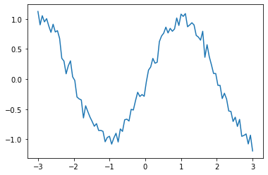

```python
import matplotlib.pyplot as plt
x = np.linspace(-3,3,100)
t = np.random.randn(x.size)*0.1
y = np.sin(np.pi*x/2) + t
y = y.reshape(-1,1)
plt.plot(x,y)
#X = np.c_[x,t]
X = x.reshape(-1,1)
N = x.size
```

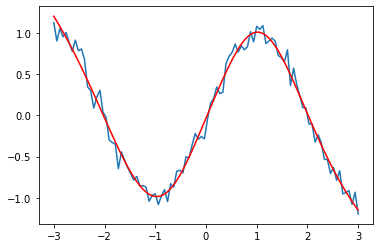

```python
weights,bias = init_weights((10,1),X.shape[1])

error = []
for i in range(10000):
    ypred,a,z = feed_forward(X,weights,bias)
    error.append(np.mean((y-ypred)**2))
    dWeight, dBias = backpropagate(X,y,a,z,weights,bias)
    weigts, bias = update_weights(weights,bias,dWeight,dBias,0.5)

#plt.plot(error)
#plt.figure()
plt.plot(x,y)
plt.plot(x,ypred,"r")
```